# Where Electoral Votes Are, and Where They Are Contested

Fifty-one rows, two inequalities, and the difference between where the votes are and where they matter

Democracy’s Data

Last updated September 13, 2026 at 10:53a EDT

Americans do not elect a president. They elect fifty-one separate slates of electors — one for each state and the District of Columbia, under fifty-one separate rules — and it is the electors, meeting in December, who elect the president. A state’s **electoral votes** are the number of electors it sends: its seats in the House plus its two senators. Electors are pledged to a candidate and almost always vote as pledged; the rare **faithless elector** who does not has never changed an outcome, and since 2020 a state may lawfully remove one.[^1] Nearly everyone agrees the system is unequal; the live argument is about **which inequality is the important one.** One candidate is the small-state bonus: every state gets two electors for its senators regardless of population, so Wyoming’s 3 electors cover far fewer people than California’s 54. The other is winner-take-all: forty-eight states award every elector to the plurality winner — whoever has the most votes, a majority or not — erasing the losing side of every state. These are different problems with different remedies, and a reform that fixes one can leave the other entirely untouched.

Both claims can be put to the record, because the entire 2024 result, as the law understands it, fits in fifty-one rows. This brief asks two questions of them: **where are the electoral votes — and where was the election actually contested?** The gap between those two answers is where campaign strategy lives, and it decides which inequality a reform would actually touch.

## The test

The vote columns come from Jason Timm’s `PresElectionResults` compilation (https://github.com/jaytimm/PresElectionResults), state-level shares for the 2024 presidential election, resting on the fifty-one certified state canvasses (the checked and signed official totals). The electoral votes are the 2020 census apportionment, fixed in law until 2032.[^2] This resolution is the right one, not a simplification of something better: the rule under examination operates on whole states, so a 51-row table is the object the law actually acts on.

No federal body adds up American election returns, so the compilation is a private assembly of fifty-one official publications — the ordinary way election data reaches anyone. What a certified return is, and why the national file is always somebody’s private act, is the returns-source chapter’s subject.

## The data

One row per jurisdiction: fifty states and the District of Columbia, which has had three electoral votes since the Twenty-Third Amendment was ratified in 1961.[^3] Here is Pennsylvania’s.

| State | Abbrev | Electoral votes | Harris % | Trump % | Other % | Winner | Margin |
| --- | --- | --- | --- | --- | --- | --- | --- |
| Pennsylvania | PA | 19 | 48.66 | 50.37 | 0 | Trump | 1.71 |

That row is three different kinds of thing sitting in a single line. The percentages, `harris`, `trump`, `other` and the computed `margin`, were **measured**: counted by county officials, certified by a state board, assembled by the compiler. The `ev` column was **legislated**: it was entered by hand from the apportionment, fifty-one numbers checked once against their required sum of 538. It is nonetheless the most certain number in the file, because it is a legal fact rather than an estimate. And two columns, `col` and `row`, were **drawn**: they are a design decision placing each state on the tile grid of the figures below, so the maps can show electoral weight without showing land. Nothing in the row records which is which.

Two cleaning decisions set this brief’s limits. First, the compilation records a third-party figure only sporadically, and the build turns every missing `other` into a zero. 42 of 51 jurisdictions therefore report a zero that is not a zero, and not one state’s three percentages add to 100. States reporting a zero fall short of 100 by 2.06 points on average, against 1.34 where a number was recorded. The shortfall *is* the third-party vote, sitting there unlabeled. **A zero and a missing value are not the same thing, and a spreadsheet cannot tell them apart.**

Second, one row per state with one winner per state assumes winner-take-all, and two states do not use it. Maine and Nebraska award two electors statewide and one per congressional district,[^4] and there is no cell in this schema in which a split could be expressed. A schema is a claim about how the world is arranged, and this one quietly claims that winner-take-all is universal. The cost of that claim is measured below.

> **Before you read the findings, commit to a winner and to a margin.** Under winner-take-all the 2024 result was 312–226, a margin of 86 electoral votes. Now give every state’s electors out in proportion to its two-party vote instead — its Harris and Trump votes only, third parties set aside. **Does the winner change — and what is the new margin?** Write down a name and a number. They are two separate questions, and one answer is much larger than most people expect while the other is not what the size of that change would suggest.

## What it says about democracy

Start with the map, drawn the only honest way a state-level rule can be drawn: land does not vote, so no land is drawn.

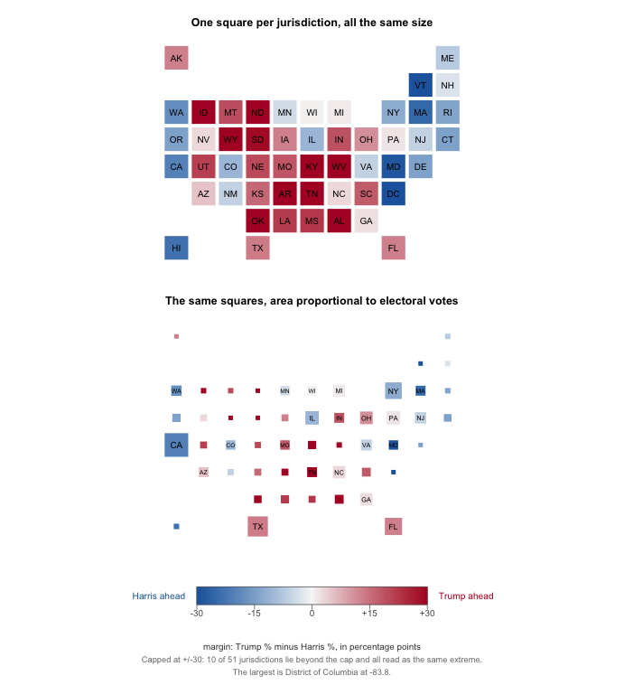

Color is the margin, capped at plus or minus 30 points, so the 10 jurisdictions beyond the cap all read as the same extreme; the largest is District of Columbia at -83.8. Hover for detail, and use the buttons to give each square an area proportional to its electoral votes.

**Figure 1. The 2024 result as a grid, drawn twice.** One square per jurisdiction fits this data, because the rule acts on whole states. Each square sits roughly where the state belongs and is colored by margin, Trump’s percentage minus Harris’s, on a scale capped at 30 points in each direction. In the first version every square is the same size, so every state counts once; in the second, a cartogram — a map that sizes each place by a number rather than by its land — each square’s area is proportional to its electoral votes, which is what the Constitution actually counts. 10 of the 51 jurisdictions lie beyond the cap and are painted the same extreme shade; the largest is District of Columbia at -83.8.

Read the legend before you read the map. The margin runs from -83.8 in District of Columbia to 45.8 in Wyoming, a spread of 130 points, and the capped scale cannot show the difference among the blowouts. A cap makes the middle of the scale readable by making the ends of it lie. **Every choropleth — a map that colours areas by a number — you will ever see has made this trade; most do not tell you.**

The color itself is a choice too. Color the same squares by Harris’s *share* instead of the margin, changing nothing else, and the country pales:

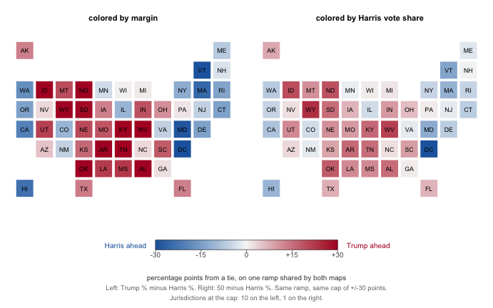

Identical geography, identical data, identical color scale; only the quantity being colored has changed. The right-hand map is the paler one because a margin is about 2.0 times the distance of a share from 50. Hover either map.

**Figure 2. Margin and share, side by side, on one color ramp.** The same 51 squares, the same blue-white-red scale, the same cap of 30 points either side of a tie. On the left, color is the gap between the two candidates; on the right it is how far Harris’s own share sits from 50. 10 jurisdictions reach the cap on the left and 1 on the right, and nothing about the country differs between the panels.

The reason is arithmetic rather than politics. A margin counts the same voters twice, once as a gain for one candidate and once as a loss for the other, so it is about 2.0 times a share’s distance from 50. Neither map is lying. **The choice of scale is an argument**, and the only dishonest version is the one that does not tell you which was chosen.

### Counting to 270, and the assumption in the count

Hand every state’s electors to whoever carried it and the total is 312 to 226, which is the certified result. But that arithmetic assumed winner-take-all everywhere, and Maine and Nebraska both split in 2024: Trump carried Maine’s second district, Harris carried Nebraska’s second.

| State | Statewide winner | Electoral votes | Margin |
| --- | --- | --- | --- |
| Maine | Harris | 4 | -6.94 |
| Nebraska | Trump | 5 | 20.46 |

Winner-take-all gives Harris all 4 of Maine’s and none of Nebraska’s. Reality gave her three from Maine and one from Nebraska. Four either way — **the two errors canceled.** That is luck, not a rule, and a model that produces the right number for the wrong reason will keep producing it until the day it does not.

### Large is not the same as close

Sort the states by electoral votes and add them up: **12 states of 51 hold a majority of the Electoral College**, and the ten largest alone hold 254, which is 47% of the whole. That is where most accounts of the Electoral College stop: a handful of big states hold the presidency, so a campaign should go where the electoral votes are.

The margin column changes the picture completely. Only 4 of those 12 states were decided by less than five points. California, Texas, New York, Illinois and Ohio are enormous and were never in doubt; they contribute electoral votes to a total, not decisions to a contest. The states that decide an election are the ones that are **large *and* close**, and that is a much smaller set:

| State | Electoral votes | Harris % | Trump % | Margin |
| --- | --- | --- | --- | --- |
| Pennsylvania | 19 | 48.66 | 50.37 | 1.71 |
| Georgia | 16 | 48.53 | 50.73 | 2.20 |
| North Carolina | 16 | 47.65 | 50.86 | 3.21 |
| Michigan | 15 | 48.31 | 49.73 | 1.42 |
| Minnesota | 10 | 50.92 | 46.68 | -4.24 |
| Wisconsin | 10 | 48.74 | 49.60 | 0.86 |
| Nevada | 6 | 47.49 | 50.59 | 3.10 |
| New Hampshire | 4 | 50.65 | 47.87 | -2.78 |

8 states holding 96 electoral votes, 17.8% of the College, carried the entire uncertainty of the election. Figure 3 puts every jurisdiction on the two axes at once.

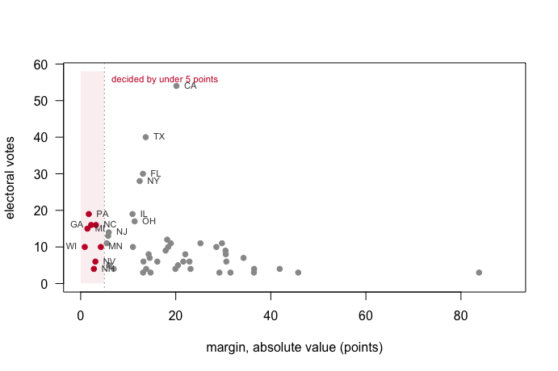

The states that decide an election sit in the top-left corner: large, and close. Hover for detail.

**Figure 3. Size against closeness, one point per jurisdiction.** The vertical axis is electoral votes and the horizontal axis is the margin, ignoring its sign; the shaded band holds the 8 jurisdictions decided by under five points. The states that decide an election sit in the upper left, large and close. The upper right is where most of the Electoral College lives: enormous, and settled before the campaign began.

**“Where the votes are” and “where the votes are in play” are different questions with almost disjoint answers**, and the whole logic of campaign strategy lives in the gap between them. This is also the strongest evidence against the standard small-state defense of the system. A small *safe* state receives essentially no attention despite its inflated per-voter weight: Wyoming, Vermont, the Dakotas. Winner-take-all swamps the senator bonus, which is Edwards’ (2004) argument at book length.[^5] Whether the net bias favors large states or small ones is still contested among people who model it carefully; Gelman, Katz and Bafumi (2004) showed the classical voting-power indexes — measures of how often one state’s electors would be the ones to tip the outcome — overstate large-state power.[^6] Both sides agree that the biggest effect is neither one: it is closeness.

### Abolish winner-take-all and see what happens

The two inequalities are separable, and that matters, because reforms are usually proposed as though they were the same problem.

| Inequality | What it does | Who it helps | Fixed by |
| --- | --- | --- | --- |
| Small-state bonus | Every state gets 2 electors for its senators regardless of size (WY 3 vs CA 54 electoral votes) | Voters in small states, of either party | Nothing short of a constitutional amendment |
| Winner-take-all | A plurality takes the whole state, so the losing side of every state is erased | Voters in close states, of either party | State law — a state could change it tomorrow |

Now run the reform the table points at. Split each state’s electors in proportion to its two-party vote instead of awarding them all to the winner:

| Rule | Harris | Trump | Margin |
| --- | --- | --- | --- |
| Winner-take-all (actual) | 226 | 312 | 86 |
| Proportional within each state | 264 | 274 | 10 |

**The margin collapses from 86 electoral votes to 10. Trump still wins.** Check the two numbers you wrote down against those.

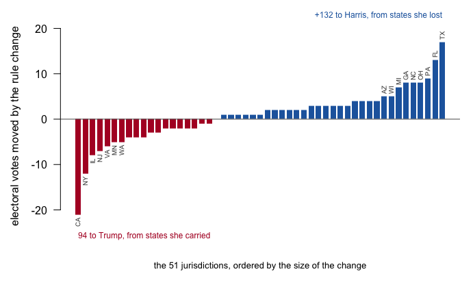

One bar per jurisdiction, ordered by the size of the change. 20 of the 51 jurisdictions move by two electoral votes or fewer. Hover for the proportional split in any state.

**Figure 4. Electoral votes moved by replacing winner-take-all with proportional allocation.** One bar per jurisdiction, ordered by the size of the change; blue bars move electors to Harris, red bars to Trump. The reform hands her 132 electors out of states she lost and takes 94 out of states she carried, and 20 of the 51 jurisdictions move by two electoral votes or fewer.

How far a state moves is almost entirely a matter of how large it is, and hardly at all a matter of how close it was. The size of the move correlates 0.99 with a state’s electoral votes. Proportional allocation is fairer to **voters in landslide states** — a Republican in California and a Democrat in Wyoming would finally count for something. It is emphatically not fairer to **small states**, which keep their two-senator bonus under either rule. The reform changes *which* inequity you live with, and it does not touch the malapportionment — the unequal number of voters standing behind each elector — at the heart of the system. And the rule producing the concentration in Figure 3 is written in state law rather than in the Constitution, and could be changed by any legislature that wanted to.[^7]

## What this brief cannot tell you

**There are no people in this file.** The vote columns are percentages and `ev` is a legal quantity, so turnout, population and votes per elector cannot be computed here, and the per-voter inequality the small-state argument turns on is out of reach. Everything is state-level, which hides the rule’s most important feature: a state’s losing voters vanish, and the file has no unit small enough to show the disappearance.

**It cannot separate the rule from the country.** Close states would be more interesting than safe ones under almost any system; winner-take-all sharpens the difference, and nothing here separates the sharpening from the underlying distribution.

**It is one election.** Competitiveness is a property of a state *in a given election*, not of the state: the Solid South was uncompetitive for eighty years and then was not, and Vermont ran the same path in reverse. The 8 competitive states of 2024 are a snapshot of a single November.

**And the reform arithmetic holds the world constant.** Change the rule and you change the campaign, the turnout and probably the vote itself. What proportional allocation would actually do is not what it does to a fixed set of votes.

## What you should have learned

- 12 states hold a majority of the Electoral College, but only 4 of them were decided by under five points: where the electoral votes are and where they are contested are nearly disjoint questions.
- The 2024 election’s entire uncertainty sat in 8 states holding 17.8% of the College, and that list is a property of the election, not of the states.
- The Electoral College’s two inequalities are independent: proportional allocation would have cut the 2024 margin from 86 electoral votes to 10 without changing the winner, and without touching the two-senator bonus.
- A margin scale spans about 2.0 times what a share scale spans for the same result, because it counts every voter twice; which one a map uses is an argument.
- In this file, 42 of 51 jurisdictions report a third-party zero that is really a missing value, and no state’s percentages sum to 100.

## Extensions

- `pres2024_states.csv` has `ev` and `margin` for every state. Sort by `margin` and add up the electoral votes of the closest states until you cross 270. How much of the map was actually in play?
- The `other` column of `pres2024_states.csv` is zero in most rows. Compute each state’s shortfall from 100 using `harris`, `trump` and `other`, and compare the states with a zero against the states without one. What is the zero hiding?
- Using `ev` and `winner` in `pres2024_states.csv`, find the smallest combination of states that reaches 270. How few jurisdictions is that?
- **Stretch.** The same compilation carries every election back to 1864. Download 2020, rebuild Figure 3, and see how much of the competitive list survives one cycle.
- **Stretch.** Maine and Nebraska publish district-level results. Download them and compute how often, since 2000, a split elector would have decided the presidency.

## Sources

**Data**

- State-level 2024 presidential returns, from Jason Timm’s `PresElectionResults` compilation (https://github.com/jaytimm/PresElectionResults), which rests on the certified state canvasses. Electoral vote counts reflect the 2020 census apportionment.
- U.S. Census Bureau. *2020 Census Apportionment Results*, the House seats, and so the electors, each state holds through 2028. https://www.census.gov/data/tables/2020/dec/2020-apportionment-data.html
- Maine and Nebraska’s district rules: 21-A M.R.S. §802 and Neb. Rev. Stat. §32-710. https://legislature.maine.gov/statutes/21-A/title21-Asec802.html https://nebraskalegislature.gov/laws/statutes.php?statute=32-710

**The data itself**

Every figure above is drawn from these tables. They are plain CSV, they open in a spreadsheet, and they are yours to take further.

`pres2024_states.csv`

**Academic literature**

- Edwards, G. C. III (2004). *Why the Electoral College Is Bad for America.* New Haven: Yale University Press. https://yalebooks.yale.edu/book/9780300109689/why-the-electoral-college-is-bad-for-america/
- Gelman, A., Katz, J. N. and Bafumi, J. (2004). “Standard Voting Power Indexes Do Not Work: An Empirical Analysis.” *British Journal of Political Science* 34(4): 657–674. https://doi.org/10.1017/S0007123404000237
- *Chiafalo v. Washington*, 591 U.S. 578 (2020), and *McPherson v. Blacker*, 146 U.S. 1 (1892). https://www.law.cornell.edu/supremecourt/text/19-465 https://www.law.cornell.edu/supremecourt/text/146/1

Rebuild this data yourself, with an AI assistant

```
I want to rebuild a public dataset from its original source, without
any starting files. Please do the following and show your work.

THE SOURCE. Jason Timm's PresElectionResults collection on GitHub,
the state-level presidential returns file:
https://github.com/jaytimm/PresElectionResults/raw/master/data/pres_by_state.rda
No account or key is needed. It is an .rda file -- R's own data
format -- so read it in R, or with a library that can open R data
files. One row is one state in one election year; keep 2024. The
compilation is assembled from public election records; it is
somebody's careful stapling of fifty-one official sources, not an
official file itself, because no official national file exists.

One thing the source does not carry: electoral votes. Those are a
fact about the 2020 census apportionment, not about the returns, so
transcribe them yourself -- fifty-one small numbers -- and prove the
transcription by checking the sum.

WHAT TO BUILD.
1. One row per state plus the District of Columbia: the Harris,
   Trump, and other vote shares, the winner, the margin, and the
   state's electoral votes.

CHECK YOUR WORK. The copy this book used was downloaded in August 2026.
If your rebuild matches it, you should find:
- 51 rows, and electoral votes that sum to exactly 538
- Trump carries 31 of the 51, Harris 20
- the two biggest prizes are California at 54 and Texas at 40
The 2024 returns are settled history and should not move; the
collection itself grows by one election every four years.
```

[^1]: *Chiafalo v. Washington*, 591 U.S. 578 (2020): https://www.law.cornell.edu/supremecourt/text/19-465. The National Archives keeps the tally of faithless votes in each election and notes that none has ever changed a result: https://www.archives.gov/electoral-college/faq.
[^2]: The Census Bureau’s apportionment table, which sets each state’s House seats and therefore its electors for the elections of 2024 and 2028: https://www.census.gov/data/tables/2020/dec/2020-apportionment-data.html.
[^3]: Text of the amendment: https://www.archives.gov/founding-docs/amendments-11-27.
[^4]: Maine’s rule is 21-A M.R.S. §802, https://legislature.maine.gov/statutes/21-A/title21-Asec802.html; Nebraska’s is Neb. Rev. Stat. §32-710, https://nebraskalegislature.gov/laws/statutes.php?statute=32-710.
[^5]: George C. Edwards III, *Why the Electoral College Is Bad for America* (New Haven: Yale University Press, 2004), https://yalebooks.yale.edu/book/9780300109689/why-the-electoral-college-is-bad-for-america/.
[^6]: Andrew Gelman, Jonathan N. Katz and Joseph Bafumi, “Standard Voting Power Indexes Do Not Work: An Empirical Analysis,” *British Journal of Political Science* 34, no. 4 (2004): 657–674, https://doi.org/10.1017/S0007123404000237.
[^7]: Article II, Section 1 leaves the manner of appointing electors to each state’s legislature: https://www.archives.gov/founding-docs/constitution-transcript. The Supreme Court confirmed how broad that power is in *McPherson v. Blacker*, 146 U.S. 1 (1892), upholding Michigan’s short-lived district system: https://www.law.cornell.edu/supremecourt/text/146/1.